# Time Series and Neural Networks

##### Revisión de autocorrelación

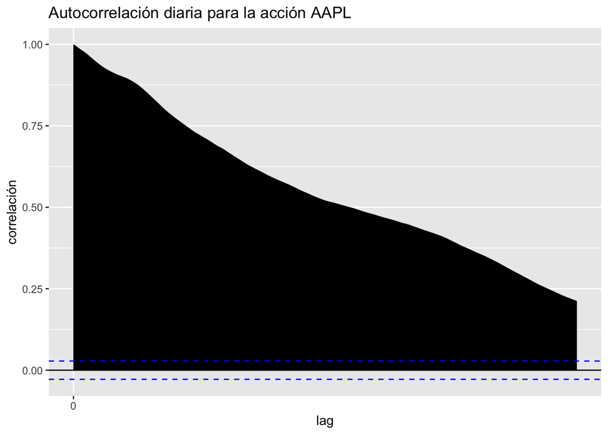

```r
autoplot(TSA::acf(st, type = "correlation", lag = 1200, plot = FALSE)) +
    labs(title = paste("Autocorrelación diaria para la acción", stock_name),
       x     = "lag",
       y     = "correlación")
```

**Conclusión** Se aprecia que existe fuerte autocorrelación pero por tramos tal como se había sospechado en el análisis gráfico.

##### Prueba de Cox-Stuar

```r
alpha_test <- 0.05

test_cox_diferente <- cox.stuart.test(st)

test_cox_creciente <- cox.stuart.test(st, alternative = c("right.sided"))

test_cox_decreciente <- cox.stuart.test(st, alternative = c("left.sided"))

if (test_cox_diferente$p.value < alpha_test) {
  print( paste('Se rechaza H0', 'existe evidencia de tendencia')) } else{
  print( 'No se rechaza H0, no hay evidencia de tendencia')
}
```

```
## [1] "Se rechaza H0 existe evidencia de tendencia"
```

```r
if (test_cox_creciente$p.value < alpha_test) {
  print( paste('Se rechaza H0', 'existe evidencia de tendencia creciente')) } else{
  print( 'No se rechaza H0, no hay evidencia de tendencia creciente')
  }
```

```
## [1] "Se rechaza H0 existe evidencia de tendencia creciente"
```

```r
if (test_cox_decreciente$p.value < alpha_test) {
  print( paste('Se rechaza H0', 'existe evidencia de tendencia decreciente')) } else{
  print( 'No se rechaza H0, no hay evidencia de tendencia decreciente')
  }
```

```
## [1] "No se rechaza H0, no hay evidencia de tendencia decreciente"
```

**Conclusión**

Existe evidencias para suponer tendencia creciente

##### Prueba Rho de Spearman

```r
test_spearman <- cor.test(st, time(st), method = "spearman")
if (test_spearman$p.value < alpha_test) {
  print( paste('Se rechaza H0', 'por lo que existe evidencia de autocorrelación'))
  print( paste('La correlación es ', test_spearman$estimate,
               'por lo que existe evidencia de',
               ifelse(test_spearman$estimate < 0,
                      'tendencia decreciente',
                      'tendencia creciente') ))
  } else{
  print( 'No se rechaza H0, no hay evidencia de autocorrelación')
  }
```

```
## [1] "Se rechaza H0 por lo que existe evidencia de autocorrelación"
## [1] "La correlación es  0.974906723484222 por lo que existe evidencia de tendencia creciente"
```

#### Revisión de Estacionalidad

##### Correlograma

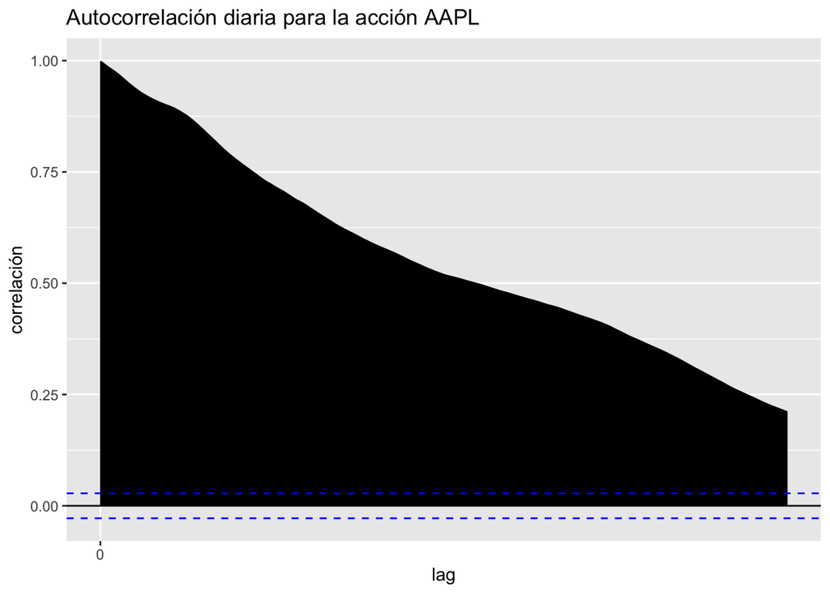

```r
autoplot(TSA::acf(st, type = "correlation", lag = 1200, plot = FALSE)) +
    labs(title = paste("Autocorrelación diaria para la acción", stock_name),
       x     = "lag",
       y     = "correlación")
```

** Conclusión ** No se evidencia la presencia de estacionalidad desde el punto de vista gráfico.

##### Gráfico de Cajas

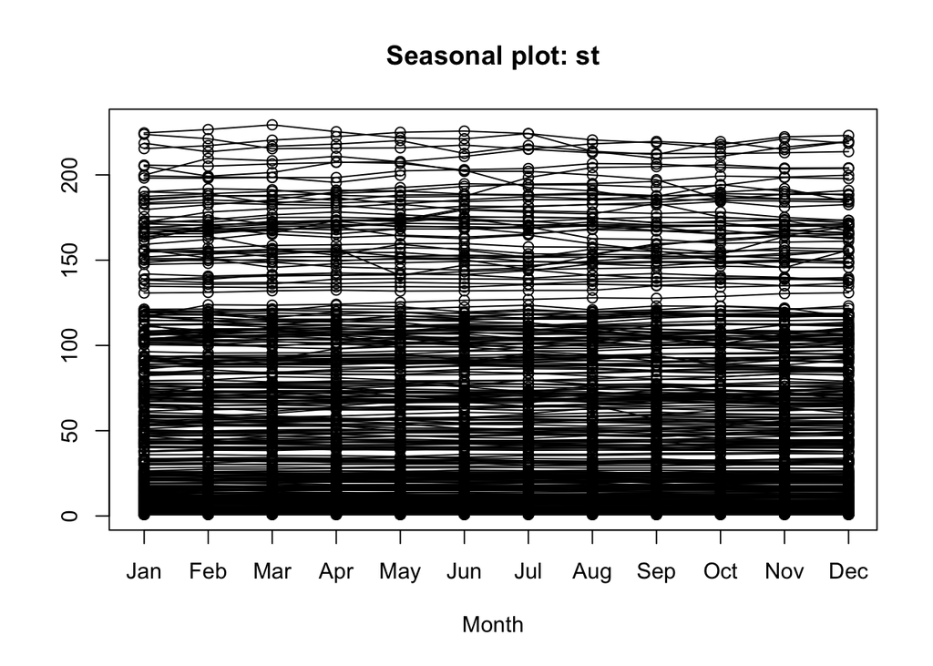

```r
seasonplot(st, s=12 )
```

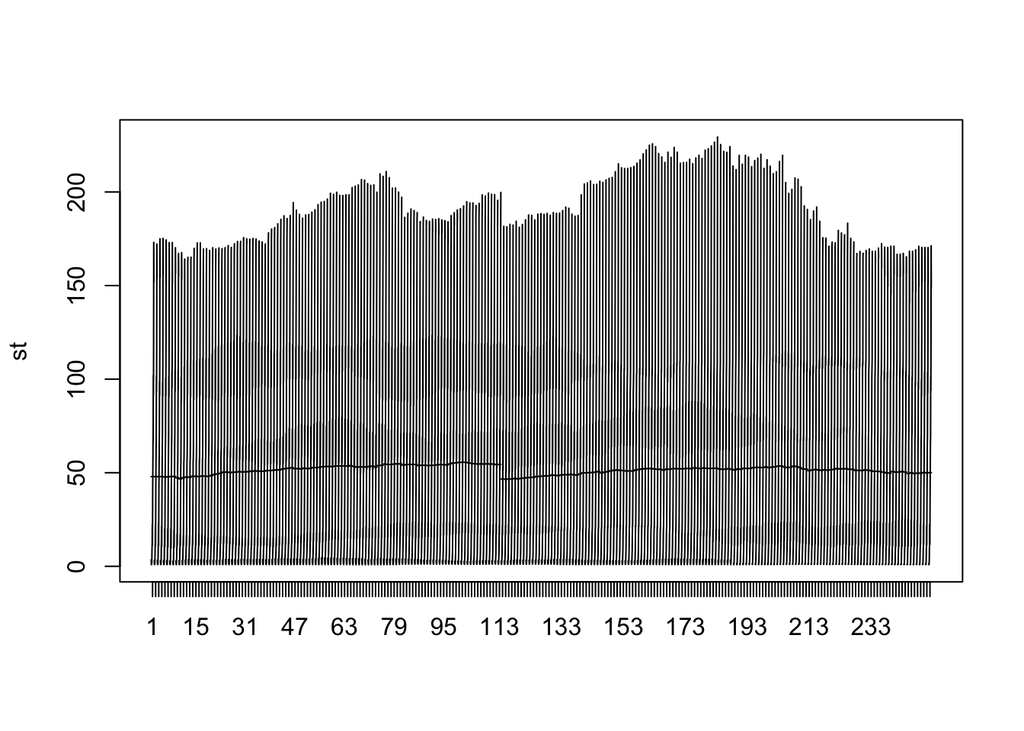

```r
monthplot(st)
```

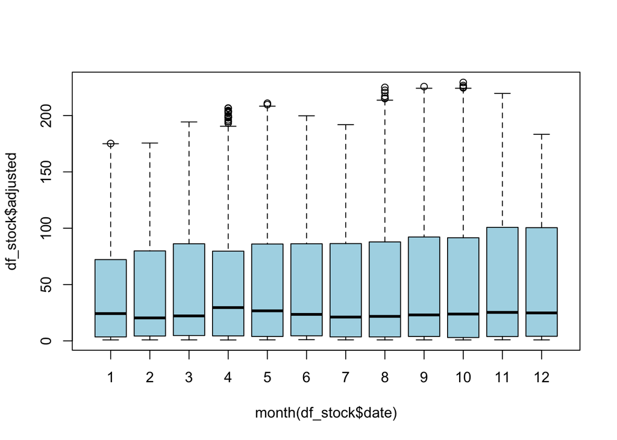

```r
boxplot(df_stock$adjusted ~ month(df_stock$date), col = "lightblue")
```

**Conclusión** Se observa que no existe estacionalidad, y la dispersión es grande.

##### Prueba de kruskal Wallis

```r
test_kruskal <- kruskal.test(st ~ cycle(st))

if (test_kruskal$p.value < alpha_test) {
  print( paste('Se rechaza H0', 'existe evidencia de estacionalidad')) } else{
  print( 'No se rechaza H0, no hay evidencia de estacionalidad')
  }
```

```
## [1] "No se rechaza H0, no hay evidencia de estacionalidad"
```

### Revisión de modelo de Regresión Lineal

Modelo: Y ~ alpha + Beta1 * t + mes

```r
Y <- st # Asignamos valores del data frame
t <- time(st) # asignamos variable tiempo de la serie
mes <- as.factor(month(df_stock$date))

mod.reg <- lm( Y ~ t + mes)

summary(mod.reg)
```

```
##
## Call:
## lm(formula = Y ~ t + mes)
##
## Residuals:
##     Min      1Q  Median      3Q     Max
## -36.586 -19.257  -5.562  15.694  93.887
##
## Coefficients:
##               Estimate Std. Error  t value Pr(>|t|)
## (Intercept) -1.853e+04  1.257e+02 -147.388   <2e-16 ***
## t            9.245e+00  6.256e-02  147.775   <2e-16 ***
## mes2         8.307e-01  1.750e+00    0.475   0.6350
## mes3         2.455e+00  1.695e+00    1.448   0.1477
## mes4         2.936e+00  1.718e+00    1.709   0.0875 .
## mes5         3.849e+00  1.705e+00    2.258   0.0240 *
## mes6         2.498e+00  1.707e+00    1.464   0.1434
## mes7         2.483e-01  1.732e+00    0.143   0.8860
## mes8         2.621e+00  1.708e+00    1.534   0.1250
## mes9         1.878e+00  1.752e+00    1.072   0.2840
## mes10        2.520e+00  1.711e+00    1.473   0.1408
## mes11        1.379e+00  1.744e+00    0.791   0.4292
## mes12       -1.294e+00  1.734e+00   -0.746   0.4558
## ---
## Signif. codes:  0 '***' 0.001 '**' 0.01 '*' 0.05 '.' 0.1 ' ' 1
##
## Residual standard error: 24.58 on 4888 degrees of freedom
## Multiple R-squared:  0.8173, Adjusted R-squared:  0.8169
## F-statistic:  1823 on 12 and 4888 DF,  p-value: < 2.2e-16
```

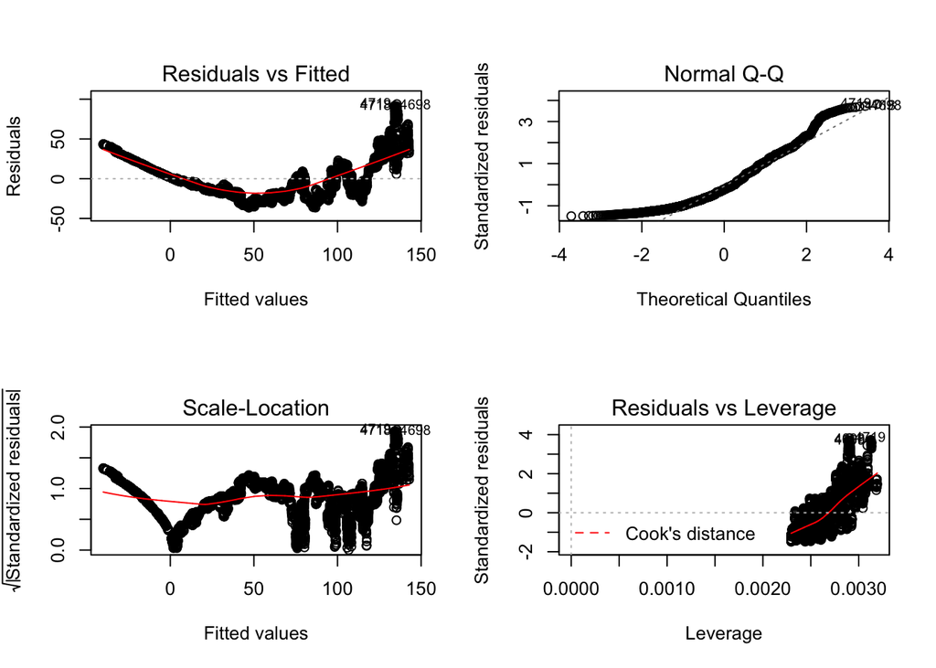

```r
par(mfrow = c(2,2))

plot(mod.reg)
```

```r
par(mfrow = c(1,1))
```

**Conclusión**

#### Predicción

Pronosticaremos el valor con base a la informaci?n disponible:

```r
t_actual <- max(time(st)) + 1/251.25

data_predict = data.frame(t= t_actual,
                          mes=5  )

data_predict$mes = as.factor(data_predict$mes)

# predict con intervalo de confianza del 95%
predict(mod.reg, newdata = data_predict, interval=c("confidence"), level = 0.95)
```

```
##        fit      lwr      upr
## 1 143.5485 140.9334 146.1637
```

El valor de la acción para el 24 de mayo 2019 de AAPL fue: 178.97

[Cotización 24 May 2019](https://www.marketwatch.com/investing/stock/aapl)

*** Graficando los valores observados y pronosticados**

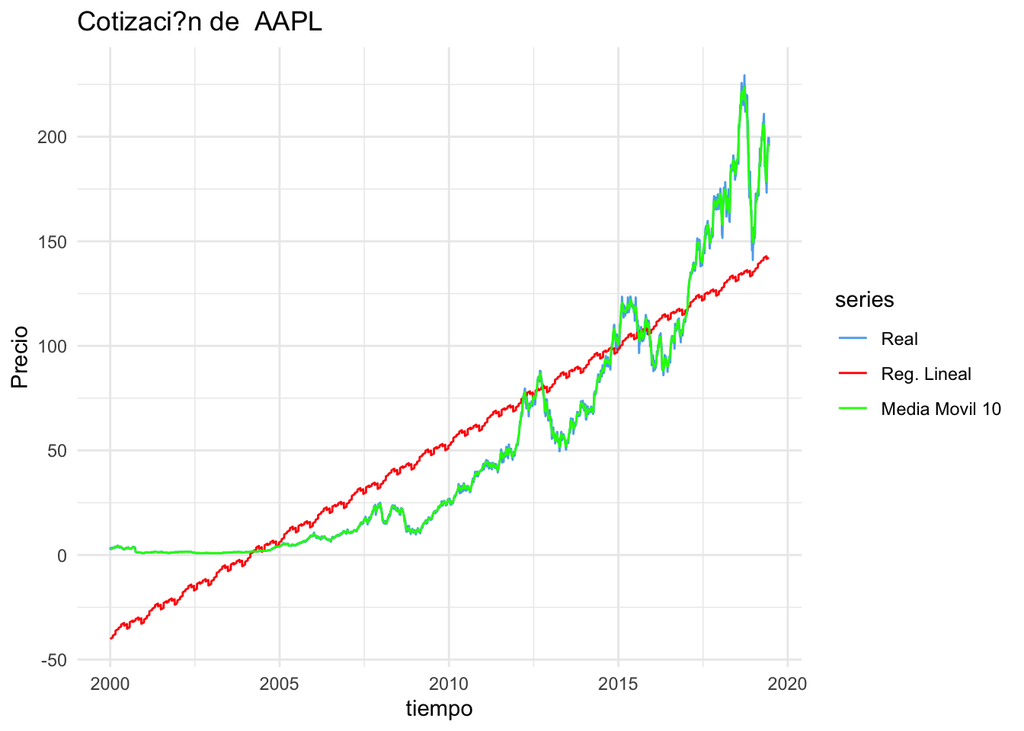

```r
data_predict <- data.frame( t = time(st),
                            mes = month(df_stock$date))

data_predict$mes = as.factor(data_predict$mes)

# predict
y_estimado <- predict(mod.reg, newdata = data_predict)


mmov <- ma(st, order = 10, centre = FALSE) # semanal

st_y_estimado <- ts( y_estimado, freq = frecuencia_st, start = c(2000,1,3) )

autoplot(cbind(st, st_y_estimado, mmov) , facets = FALSE) +
  labs(title = paste("Cotizaci?n de ", stock_name),
       x     = "tiempo",
       y     = "Precio")+
  theme(legend.position="bottom") +
  scale_colour_manual(labels = c("Real", "Reg. Lineal", "Media Movil 10"),
                      values = c("steelblue2", "red", "green")) +
  theme_minimal()
```

### Selección del mejor modelo de suavización exponencial

**Holt Winters : Aditivo**

```r
mod.HWA = HoltWinters(st, alpha = NULL, beta = NULL, gamma = NULL, seasonal = c("additive"))

sprintf('[ alpha = %f ][ beta = %f][ gamma = %f ] ',mod.HWA$alpha, mod.HWA$beta, mod.HWA$gamma)
```

```
## [1] "[ alpha = 1.000000 ][ beta = 0.000987][ gamma = 0.090077 ] "
```

**Diagnóstico de los residuales**

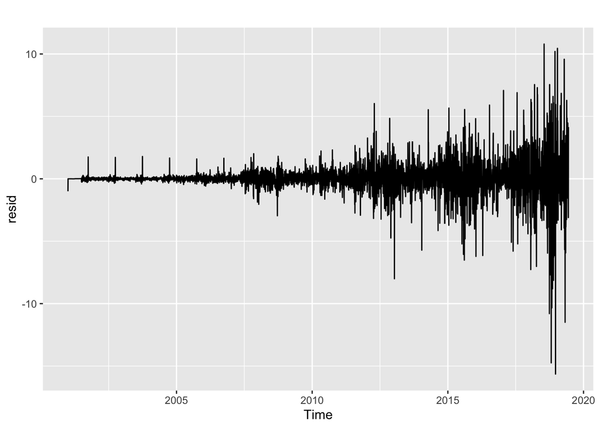

```r
resid = residuals(mod.HWA)
autoplot(resid)
```

**Holt Winters : Multiplicativo**

```r
mod.HWM = HoltWinters(st, alpha = NULL, beta = NULL, gamma = NULL, seasonal = c("multiplicative"))

sprintf('[ alpha = %f ][ beta = %f][ gamma = %f ] ',mod.HWM$alpha, mod.HWM$beta, mod.HWM$gamma)
```

```
## [1] "[ alpha = 0.782295 ][ beta = 0.000000][ gamma = 1.000000 ] "
```

**Diagnóstico de los residuales**

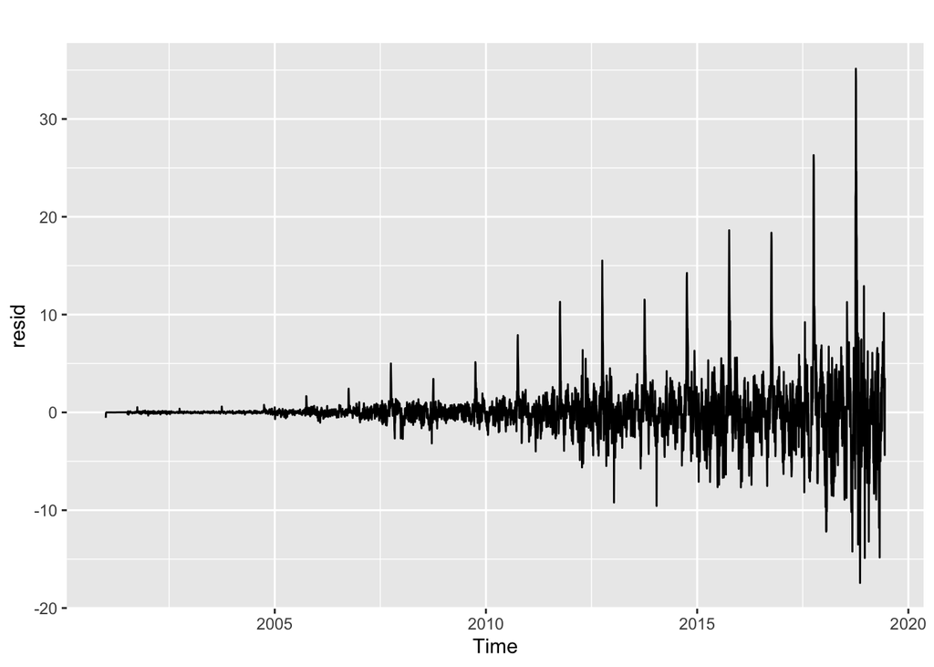

```r
resid = residuals(mod.HWM)
autoplot(resid)
```

### Neural Network

```r
library(keras)
library(astsa)


head(st)
```

```
## Time Series:
## Start = c(2000, 1)
## End = c(2000, 6)
## Frequency = 252
##      adjusted
## [1,] 3.502161
## [2,] 3.206892
## [3,] 3.253822
## [4,] 2.972241
## [5,] 3.113032
## [6,] 3.058280
```

```r
# revisando retornos

##st_return <- diff(log(st))

##plot(st_return)

##acf2(st_return)

##auto.arima(st_return)
```

```r
## sarima(st_return, p = 1, d = 0, q = 0)
```

```r
# preparing data

# st_window: number of lags to construct matrix x to
st_window <- 3

# x <- matrix( NA , nrow = length(st) - st_window, ncol = st_window  )
#
# for i in (1:st_windo){
#
#
# }
#
#
#
#
#
#
#
# model <- keras_model_sequential() %>%
# layer_embedding(input_dim = max_features, output_dim = 32) %>%
# layer_lstm(units = 32) %>%
# layer_dense(units = 1, activation = "sigmoid")
# model %>% compile(
# optimizer = "rmsprop",
# loss = "binary_crossentropy",
# metrics = c("acc")
# )
# history <- model %>% fit(
# input_train, y_train,
# epochs = 10,
# batch_size = 128,
# validation_split = 0.2
# )
```